# 1-ый этап индивидуального проекта

Основы информационной безопасности

Верниковская Е. А., НПИбд-01-23

Российский университет дружбы народов, Москва, Россия

20 февраля 2025

# Вводная часть

## Цель работы

Научиться основным способам тестирования веб приложений. Установка Kali Linux

## Задание

1. Установить дистрибутив Kali Linux в виртуальную машину.

# Выполнение 1-ого этапа индивидуального проекта

## Создание виртуальной машины

Скачиваем Kali Linux (рис. 1)

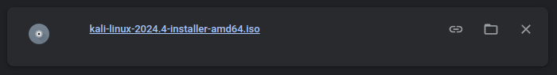

Установка Kali Linux с сайта

## Создание виртуальной машины

Указываем имя виртуальной машины, определяем тип операционной системы и указываем путь к iso-образу (рис. 2)

[figure not shown]

Создание виртуалтной машины (1)

## Создание виртуальной машины

Далее указываем размер оперативной памяти виртуальной машины - 4096 МБ и число процессоров - 3 (рис. 3)

[figure not shown]

Создание виртуалтной машины (2)

## Создание виртуальной машины

Задаём размер виртуального жёсткого диска - 40 ГБ (рис. 4)

[figure not shown]

Создание виртуалтной машины (3)

## Создание виртуальной машины

Далее запускаем установку систему (рис. 5)

[figure not shown]

Запуск установки системы

## Установка операционной системы

После запуска устанавливаем русский язык интерфейса (рис. 6)

[figure not shown]

Язык интерфейса - русский

## Установка операционной системы

Выбираем местонахождение - Российская Федерация (рис. 7)

[figure not shown]

Выбор местонахождения

## Установка операционной системы

Добавляем русскую раскладку клавиатуры (рис. 8)

[figure not shown]

Настройка раскладки клавиатуры

## Установка операционной системы

После настраиваем клавиатуру. Указываем способ переключения клавиатуры между национальносй раскладкой и стандартной латинской раскладкой - Alt+Shift (рис. 9)

[figure not shown]

Настройка переключения раскладки

## Установка операционной системы

Далее настраиваем сеть. Вводим имя компьютера и имя домена (рис. 10), (рис. 11)

[figure not shown]

Настройка сети (1)

## Установка операционной системы

[figure not shown]

Настройка сети (2)

## Установка операционной системы

После настраиваем учётную запись пользователя. Вводим полное имя пользователя и имя нашей учётной записи. Также задаём пароль для нашего пользователя (рис. 12), (рис. 13), (рис. 14)

[figure not shown]

Настройка учётной записи пользователя и пароля (1)

## Установка операционной системы

[figure not shown]

Настройка учётной записи пользователя и пароля (2)

## Установка операционной системы

[figure not shown]

Настройка учётной записи пользователя и пароля (3)

## Установка операционной системы

Далее настраиваем время. Выбираем нужный нам часовой пояс (рис. 15)

[figure not shown]

Настройка времени

## Установка операционной системы

Далее установщик предлагает разметку дисков. Так как созданный виртуальный диск пустой, выбираем “использовать весь диск”. После, выбираем нужный диск для разметки. Далее предлагается выбрать одну из схем разметки. Оставляем рекомендуемую схему разметки, т.е. первую, “все файлы в одном разделе”. После этого заканчиваем разметку и подтверждаем что мы хотим записать изменения на диск (рис. 16), (рис. 17), (рис. 18), (рис. 19), (рис. 20)

## Установка операционной системы

[figure not shown]

Разметка дисков (1)

## Установка операционной системы

[figure not shown]

Разметка дисков (2)

## Установка операционной системы

[figure not shown]

Разметка дисков (3)

## Установка операционной системы

[figure not shown]

Разметка дисков (4)

## Установка операционной системы

[figure not shown]

Разметка дисков (5)

## Установка операционной системы

Далее предлагается выбор метапакетов, которые могут быть установлены. Выбор по умолчанию установит стандартную систему Kali Linux, поэтому оставляем выбор по умолчанию (рис. 21)

[figure not shown]

Выбор прграммного обеспечения

## Установка операционной системы

Далее подтверждаем установку системного загрузчика GRUB (загрузчик операционной системы от проекта GNU программа для управления процессом загрузки), также выбираем виртуальный диск, на который устанавливать GRUB (рис. 22), (рис. 23)

[figure not shown]

Установка системного загрузчика GRUB (1)

## Установка операционной системы

[figure not shown]

Установка системного загрузчика GRUB (2)

## Установка операционной системы

После этго ждём завершение установки перезагружаем систему (рис. 24)

[figure not shown]

Завершение установки

## После установки

После установки ОС и перезапуска ВМ входим в ОС под заданной нами при установке учётной записью (рис. 25), (рис. 26)

[figure not shown]

Вход в учётную запись

## После установки

[figure not shown]

Kali Linux :)

# Подведение итогов

## Выводы

В ходе выполнения 1-ого этапа индивидуального проекта мы установили дистрибутив Kali Linux в виртуальную машину

## Список литературы

1. Этапы реализации проекта [Электронный ресурс] URL: https://esystem.rudn.ru/mod/page/view.php?id=1220336
2. VirtualBox [Электронный ресурс] URL: https://www.virtualbox.org/wiki/Linux_Downloads
3. Kali Linux [Электронный ресурс] URL: https://www.kali.org/get-kali/#kali-platforms